# vaccines-2

```
/home/yonatan/.local/share/jupyter/runtime/kernel-v2-5417KpAsYqpYieXm.json
```

##### Plot distribution of studies' N values

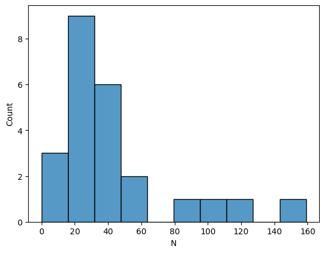

##### Narrow to large datasets only

|  | Dataset | N |
| --- | --- | --- |
| 6 | GSE41080.SDY212 | 89 |
| 9 | GSE48018.SDY1276 | 115 |
| 10 | GSE48023.SDY1276 | 110 |
| 22 | SDY67 | 159 |

##### Narrow to a specific dataset and day, then keep only relevant columns

```
*** Multiple accession detected! Collapsing by averaging on IMMAGE value ***

Working with dataset GSE41080.SDY212
Working with strain B/Florida/4/2006
Total subjects in study: N=89
available strains: ['A/Brisbane/10/2007' 'B/Florida/4/2006' 'A/Brisbane/59/2007']
```

|  | IMMAGE | Response | Age |
| --- | --- | --- | --- |
| 0 | 0.237785 | 80.0 | 24.07 |
| 1 | 0.155243 | 10.0 | 24.97 |
| 2 | 0.112590 | 40.0 | 84.06 |
| 3 | -0.100949 | 80.0 | 61.84 |
| 4 | -0.226173 | 40.0 | 62.86 |

##### Plot IMMAGE, response, and age values to look at the dynamic range

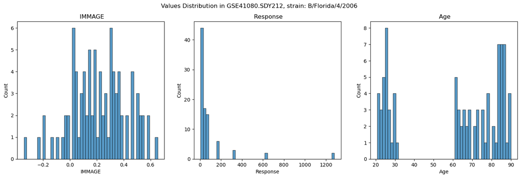

##### Is there a trend like we expect? (High IMMAGE ⇒ low response)

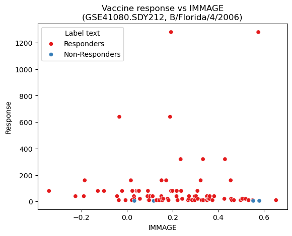

##### Classifying with logistic regression - cross validation

```
Mean classification accuracy (logistic regression): 0.9555555555555555
```

##### Classifying with logistic regression - fitting the entire dataset, and checcking the threshold

```
IMMAGE cutoff value is: 8.643295637669205
```

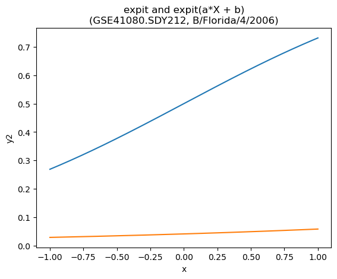

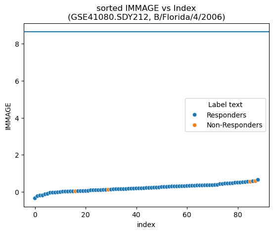

##### Logistic regreesion preforms badly, but maybe it still assigns probabilities in a way that makes sense?

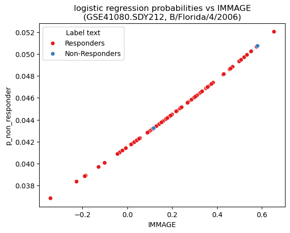

That's a good sign that the regressor picked up on an underlying dynamic in the direction that we were expecting.

##### Since this is the case, maybe an ROC curve where we shift the decision threshold based on probability will still work. (The default for log. reg. is to put the decision boundary at p=0.5)

##### The focus here is to find a threshold for classifying *non-repsponders* which maximizes the proportion of non-responders in the predicted group, not caring about predicting responders for now.

```
optimal threshold:  0.55 (IMMAGE value)
```

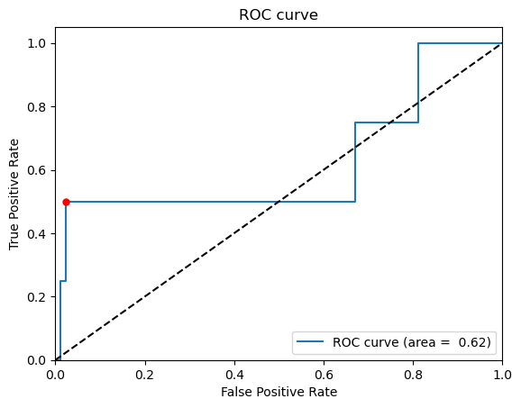

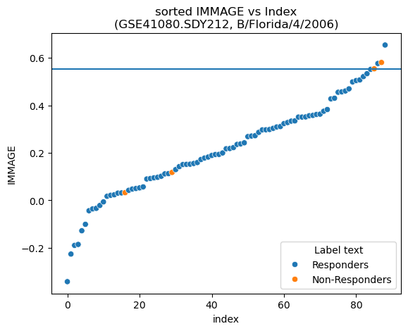

An alternative is to try hard IMMAGE-based thresholds:

```
optimal threshold:  0.12 (IMMAGE value)
```

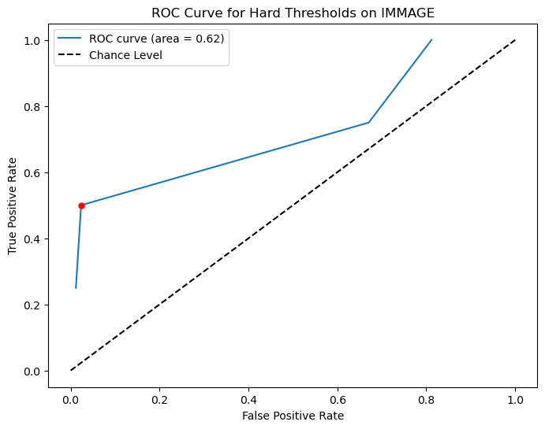

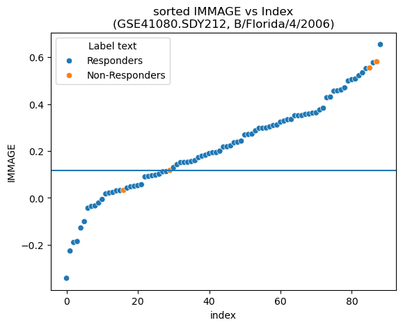

##### Which give a different threshold with the same AUC score

##### Another option it to bin IMMAGE values and look for where the rate of non-responders changes

##### TODO: We can make this more elaborate by using different # of bins and making and ROC from the maximum rate we find in each

```
   bin   NR rate
0    0  0.000000
1    1  0.000000
2    2  0.076923
3    3  0.000000
4    4  0.000000
5    5  0.200000
```